# HW #2: Visualizing FEMA NRI Data

Assigned Wed 01/21/2026 | Due Wed 01/28/2026

Author

Ixel M.

```r
# Upload necessary librarys
library(tidyverse)
library(janitor)
library(here)
```

## Visualization Goal:

How do FEMA National Risk Index scores for counties in California compare to those in other states? This may require some data wrangling.

```r
# Load in datafile
nr_index <- read_csv(here("data/National_Risk_Index_Counties_807384124455672111.csv"))
view(nr_index)
```

# Data exploration

```r
# Quck overview
head(nr_index)
# View column names and types
glimpse(nr_index)
# Summary statistics for all columns
summary(nr_index)

# Check unique values in County Type
unique(nr_index$`County Type`)
table(nr_index$`County Type`)

# Check how many states you have
unique(nr_index$`State Name`)
length(unique(nr_index$`State Name`))  # should be > 50 if territories included

# Check data type of Risk Index Score
class(nr_index$`National Risk Index - Score - Composite`)

# Look at distribution of risk scores
summary(nr_index$`National Risk Index - Score - Composite`)
hist(nr_index$`National Risk Index - Score - Composite`)
```

```r
# Count NAs in risk score column
sum(is.na(nr_index$`National Risk Index - Score - Composite`))

nr_index %>% count(`County Type`)
nr_index %>% count(`County Name`)
```

# Wrangle data for graph interpitation

```r
nri_clean <- nr_index %>%
  clean_names() %>%
  filter(county_type == "County") %>% # keep only County rows
  filter(!is.na(national_risk_index_score_composite)) %>% # remove rows with missing risk scores
  # select and rename columns
  select(state = state_name,
         state_abbr = state_name_abbreviation,
         county = county_name,
         nri_score = national_risk_index_score_composite) %>%
# Create indicator for highlighting California in the plot
  mutate(is_california = state_abbr == "CA") %>%
# Calculate state median scores to reorder states for plotting
  group_by(state_abbr) %>%
  mutate(state_median = median(nri_score)) %>%
  ungroup() %>%
  mutate(state_abbr = fct_reorder(state_abbr, state_median))

# Check clean data
glimpse(nri_clean)
summary(nri_clean)
```

# Distribution of risk scores for California counties compared to other states”

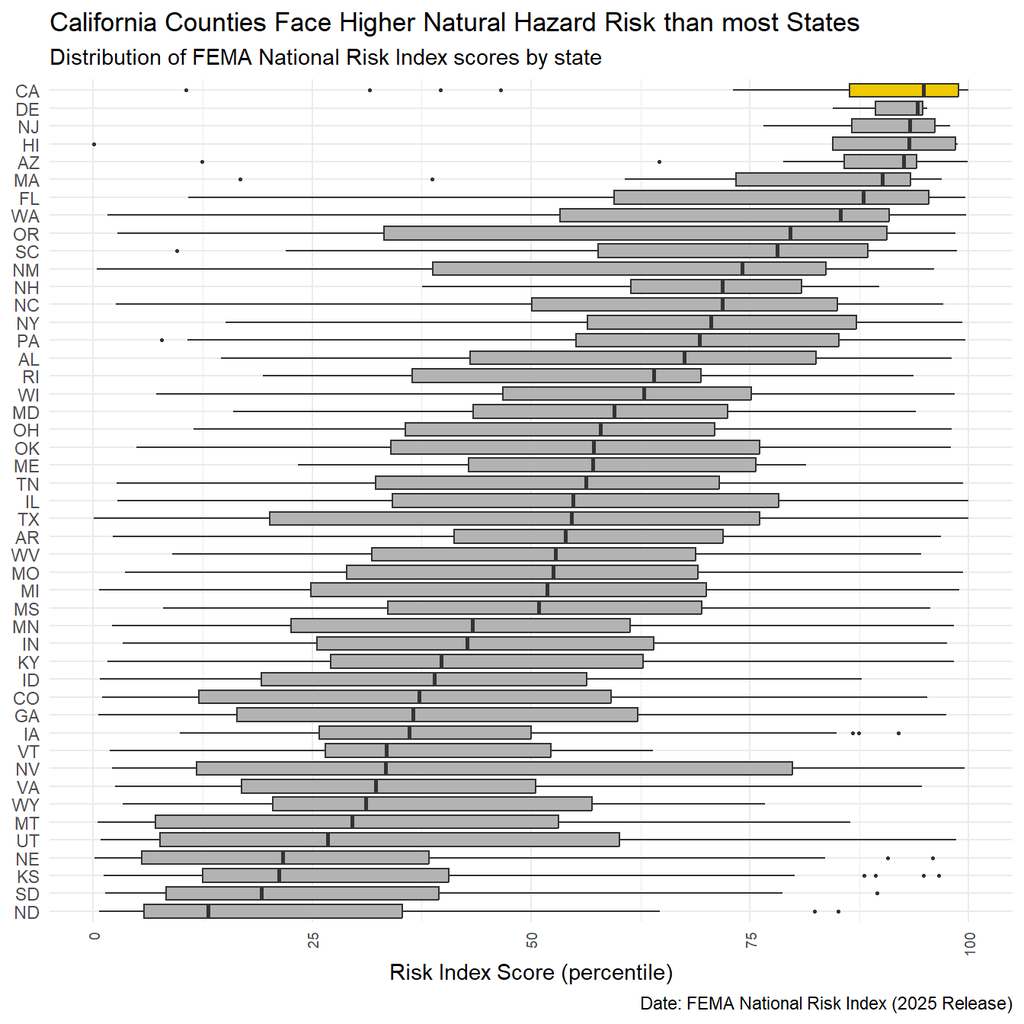

```r
ggplot(nri_clean, aes(x = state_abbr, y = nri_score, fill = is_california)) +
  geom_boxplot(outlier.size = 0.5) +
  scale_fill_manual(values = c("TRUE" = "gold2", "FALSE" = "gray70"), guide = "none") +
  labs(
    title = "California Counties Face Higher Natural Hazard Risk than most States",
    subtitle = "Distribution of FEMA National Risk Index scores by state",
    x = NULL,
    y = "Risk Index Score (percentile)",
    caption = "Date: FEMA National Risk Index (2025 Release)") +
  theme_minimal() +
  theme(axis.text.x = element_text(angle = 90, vjust = 0.5, hjust = 1, size = 7)) +
  coord_flip()
```

# Answer some questions

1. What are your variables of interest and what kinds of data (e.g. numeric, categorical, ordered, etc.) are they (a bullet point list is fine)?
- State, County Type, County Name are character (categorical) variables.
- National Risk Index - Score - Composite is a numeric (continuous) variable.
2. How did you decide which type of graphic form was best suited for answering the question? What alternative graphic forms could you have used instead? Why did you settle on this particular graphic form?

First I thought about the question and told myself I need to show distribution. Using the Data Viz decision tree, I identified several options for comparing distributions across multiple categories. I considered a ridge line plot as an alternative, which would show the full density curves for each state. However, I chose a boxplot because it clearly displays key distribution statistic (median, quartiles, and outliers) in a compact format, making it easier to quickly compare California’s risk profile against all other state at once.

3. Summarize your main finding in no more than two sentences.

My finding show that California Counties have higher natural hazard risk than most counties in other states. California’s median risk score ranks among the highest nationally, indicating elevated vulnerability to natural hazards.

4. What modifications did you make to this visualization to make it more easily readable?

I used `coord_flip()` to display state horizontally, making state lables easier to read. I also created a California indicator variable (`is_california`) to highlight California with a distint color, drawing immediate attention tot he comparison of interest. Additionally, I ordered state by their median risk score to reveal ranking patterns more clearly.

5. Is there anything you wanted to implement, but didn’t know how? If so, please describe.

I wanted to implement regional grouping to reduce visual clutter and add a reference line showing the national median,but I didn’t know how to approach these modifications.